# Risk Factor Analysis

## Outcome Variable

**Outcome Variable:** wasted

## Predictor Variables

**Intervention Variable:** predfeed36

**Adjustment Set:**

unadjusted

## Stratifying Variables

The analysis was stratified on these variable(s):

- agecat
- studyid
- country

## Data Summary

| agecat | studyid | country | predfeed36 | wasted | n_cell | n |
| --- | --- | --- | --- | --- | --- | --- |
| Birth | ki0047075b-MAL-ED | BANGLADESH | 0 | 0 | 89 | 230 |
| Birth | ki0047075b-MAL-ED | BANGLADESH | 0 | 1 | 21 | 230 |
| Birth | ki0047075b-MAL-ED | BANGLADESH | 1 | 0 | 102 | 230 |
| Birth | ki0047075b-MAL-ED | BANGLADESH | 1 | 1 | 18 | 230 |
| Birth | ki0047075b-MAL-ED | BRAZIL | 0 | 0 | 143 | 177 |
| Birth | ki0047075b-MAL-ED | BRAZIL | 0 | 1 | 6 | 177 |
| Birth | ki0047075b-MAL-ED | BRAZIL | 1 | 0 | 28 | 177 |
| Birth | ki0047075b-MAL-ED | BRAZIL | 1 | 1 | 0 | 177 |
| Birth | ki0047075b-MAL-ED | INDIA | 0 | 0 | 148 | 195 |
| Birth | ki0047075b-MAL-ED | INDIA | 0 | 1 | 31 | 195 |
| Birth | ki0047075b-MAL-ED | INDIA | 1 | 0 | 14 | 195 |
| Birth | ki0047075b-MAL-ED | INDIA | 1 | 1 | 2 | 195 |
| Birth | ki0047075b-MAL-ED | NEPAL | 0 | 0 | 123 | 167 |
| Birth | ki0047075b-MAL-ED | NEPAL | 0 | 1 | 19 | 167 |
| Birth | ki0047075b-MAL-ED | NEPAL | 1 | 0 | 24 | 167 |
| Birth | ki0047075b-MAL-ED | NEPAL | 1 | 1 | 1 | 167 |
| Birth | ki0047075b-MAL-ED | PERU | 0 | 0 | 145 | 266 |
| Birth | ki0047075b-MAL-ED | PERU | 0 | 1 | 5 | 266 |
| Birth | ki0047075b-MAL-ED | PERU | 1 | 0 | 115 | 266 |
| Birth | ki0047075b-MAL-ED | PERU | 1 | 1 | 1 | 266 |
| Birth | ki0047075b-MAL-ED | SOUTH AFRICA | 0 | 0 | 217 | 234 |
| Birth | ki0047075b-MAL-ED | SOUTH AFRICA | 0 | 1 | 14 | 234 |
| Birth | ki0047075b-MAL-ED | SOUTH AFRICA | 1 | 0 | 3 | 234 |
| Birth | ki0047075b-MAL-ED | SOUTH AFRICA | 1 | 1 | 0 | 234 |
| Birth | ki0047075b-MAL-ED | TANZANIA, UNITED REPUBLIC OF | 0 | 0 | 113 | 116 |
| Birth | ki0047075b-MAL-ED | TANZANIA, UNITED REPUBLIC OF | 0 | 1 | 2 | 116 |
| Birth | ki0047075b-MAL-ED | TANZANIA, UNITED REPUBLIC OF | 1 | 0 | 1 | 116 |
| Birth | ki0047075b-MAL-ED | TANZANIA, UNITED REPUBLIC OF | 1 | 1 | 0 | 116 |
| Birth | ki1000109-EE | PAKISTAN | 0 | 0 | 1 | 1 |
| Birth | ki1000109-EE | PAKISTAN | 0 | 1 | 0 | 1 |

[output cut: 106 more lines]

The following strata were considered:

- agecat: 24 months, studyid: ki0047075b-MAL-ED, country: BANGLADESH
- agecat: 24 months, studyid: ki0047075b-MAL-ED, country: BRAZIL
- agecat: 24 months, studyid: ki0047075b-MAL-ED, country: INDIA
- agecat: 24 months, studyid: ki0047075b-MAL-ED, country: NEPAL
- agecat: 24 months, studyid: ki0047075b-MAL-ED, country: PERU
- agecat: 24 months, studyid: ki0047075b-MAL-ED, country: SOUTH AFRICA
- agecat: 24 months, studyid: ki0047075b-MAL-ED, country: TANZANIA, UNITED REPUBLIC OF
- agecat: 24 months, studyid: ki1113344-GMS-Nepal, country: NEPAL
- agecat: 24 months, studyid: ki1148112-LCNI-5, country: MALAWI
- agecat: 24 months, studyid: kiGH5241-JiVitA-3, country: BANGLADESH
- agecat: 24 months, studyid: kiGH5241-JiVitA-4, country: BANGLADESH
- agecat: 6 months, studyid: ki0047075b-MAL-ED, country: BANGLADESH
- agecat: 6 months, studyid: ki0047075b-MAL-ED, country: BRAZIL
- agecat: 6 months, studyid: ki0047075b-MAL-ED, country: INDIA
- agecat: 6 months, studyid: ki0047075b-MAL-ED, country: NEPAL
- agecat: 6 months, studyid: ki0047075b-MAL-ED, country: PERU
- agecat: 6 months, studyid: ki0047075b-MAL-ED, country: SOUTH AFRICA
- agecat: 6 months, studyid: ki0047075b-MAL-ED, country: TANZANIA, UNITED REPUBLIC OF
- agecat: 6 months, studyid: ki1000109-EE, country: PAKISTAN
- agecat: 6 months, studyid: ki1000304b-SAS-FoodSuppl, country: INDIA
- agecat: 6 months, studyid: ki1113344-GMS-Nepal, country: NEPAL
- agecat: 6 months, studyid: ki1148112-LCNI-5, country: MALAWI
- agecat: 6 months, studyid: kiGH5241-JiVitA-3, country: BANGLADESH
- agecat: 6 months, studyid: kiGH5241-JiVitA-4, country: BANGLADESH
- agecat: Birth, studyid: ki0047075b-MAL-ED, country: BANGLADESH
- agecat: Birth, studyid: ki0047075b-MAL-ED, country: BRAZIL
- agecat: Birth, studyid: ki0047075b-MAL-ED, country: INDIA
- agecat: Birth, studyid: ki0047075b-MAL-ED, country: NEPAL
- agecat: Birth, studyid: ki0047075b-MAL-ED, country: PERU
- agecat: Birth, studyid: ki0047075b-MAL-ED, country: SOUTH AFRICA
- agecat: Birth, studyid: ki0047075b-MAL-ED, country: TANZANIA, UNITED REPUBLIC OF
- agecat: Birth, studyid: ki1000109-EE, country: PAKISTAN
- agecat: Birth, studyid: kiGH5241-JiVitA-3, country: BANGLADESH
- agecat: Birth, studyid: kiGH5241-JiVitA-4, country: BANGLADESH

### Dropped Strata

Some strata were dropped due to rare outcomes:

- agecat: Birth, studyid: ki0047075b-MAL-ED, country: BRAZIL
- agecat: Birth, studyid: ki0047075b-MAL-ED, country: INDIA
- agecat: Birth, studyid: ki0047075b-MAL-ED, country: NEPAL
- agecat: Birth, studyid: ki0047075b-MAL-ED, country: PERU
- agecat: Birth, studyid: ki0047075b-MAL-ED, country: SOUTH AFRICA
- agecat: Birth, studyid: ki0047075b-MAL-ED, country: TANZANIA, UNITED REPUBLIC OF
- agecat: Birth, studyid: ki1000109-EE, country: PAKISTAN
- agecat: Birth, studyid: kiGH5241-JiVitA-4, country: BANGLADESH
- agecat: 6 months, studyid: ki0047075b-MAL-ED, country: BANGLADESH
- agecat: 6 months, studyid: ki0047075b-MAL-ED, country: BRAZIL
- agecat: 6 months, studyid: ki0047075b-MAL-ED, country: INDIA
- agecat: 6 months, studyid: ki0047075b-MAL-ED, country: NEPAL
- agecat: 6 months, studyid: ki0047075b-MAL-ED, country: PERU
- agecat: 6 months, studyid: ki0047075b-MAL-ED, country: SOUTH AFRICA
- agecat: 6 months, studyid: ki0047075b-MAL-ED, country: TANZANIA, UNITED REPUBLIC OF
- agecat: 6 months, studyid: ki1000304b-SAS-FoodSuppl, country: INDIA
- agecat: 6 months, studyid: ki1148112-LCNI-5, country: MALAWI
- agecat: 24 months, studyid: ki0047075b-MAL-ED, country: BRAZIL
- agecat: 24 months, studyid: ki0047075b-MAL-ED, country: INDIA
- agecat: 24 months, studyid: ki0047075b-MAL-ED, country: NEPAL
- agecat: 24 months, studyid: ki0047075b-MAL-ED, country: PERU
- agecat: 24 months, studyid: ki0047075b-MAL-ED, country: SOUTH AFRICA
- agecat: 24 months, studyid: ki0047075b-MAL-ED, country: TANZANIA, UNITED REPUBLIC OF
- agecat: 24 months, studyid: ki1148112-LCNI-5, country: MALAWI

## Methods Detail

We’re interested in the causal parameters $E[Y_a]$ for all values of $a \in \mathcal{A}$. These parameters represent the mean outcome if, possibly contrary to fact, we intervened to set all units to have $A=a$. Under the randomization and positivity assumptions, these are identified by the statistical parameters $\psi_a=E_W[E_{Y|A,W}(Y|A=a,W)]$. In addition, we’re interested in the mean of $Y$, $E[Y]$ under no intervention (the observed mean). We will estimate these parameters by using SuperLearner to fit the relevant likelihood factors – $E_{Y|A,W}(Y|A=a,W)$ and $p(A=a|W)$, and then updating our likelihood fit using a joint TMLE.

For unadjusted analyses ($W=\{\}$), initial likelihoods were estimated using Lrnr_glm to estimate the simple $E(Y|A)$ and Lrnr_mean to estimate $p(A)$. For adjusted analyses, a small library containing Lrnr_glmnet, Lrnr_xgboost, and Lrnr_mean was used.

Having estimated these parameters, we will then use the delta method to estimate relative risks and attributable risks relative to a prespecified baseline level of $A$.

# Results Detail

## Results Plots

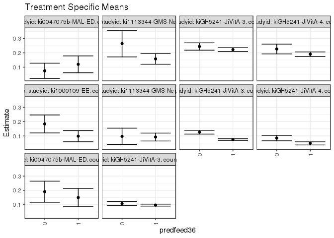

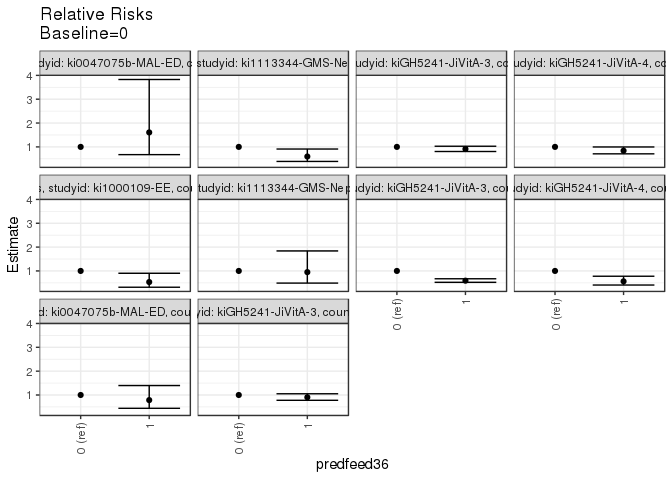

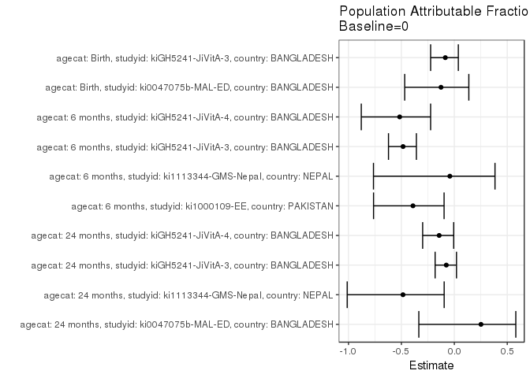

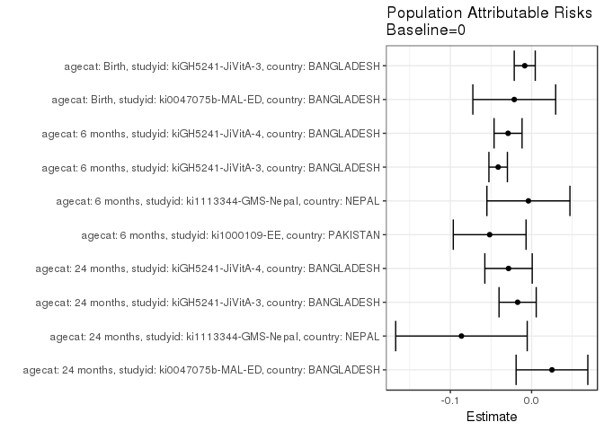

## Results Table

### Parameter: TSM

| agecat | studyid | country | intervention_level | baseline_level | estimate | ci_lower | ci_upper |
| --- | --- | --- | --- | --- | --- | --- | --- |
| Birth | ki0047075b-MAL-ED | BANGLADESH | 0 | NA | 0.1909091 | 0.1173037 | 0.2645145 |
| Birth | ki0047075b-MAL-ED | BANGLADESH | 1 | NA | 0.1500000 | 0.0859737 | 0.2140263 |
| Birth | kiGH5241-JiVitA-3 | BANGLADESH | 0 | NA | 0.1076634 | 0.0934195 | 0.1219072 |
| Birth | kiGH5241-JiVitA-3 | BANGLADESH | 1 | NA | 0.0972585 | 0.0903107 | 0.1042062 |
| 6 months | ki1000109-EE | PAKISTAN | 0 | NA | 0.1836735 | 0.1209932 | 0.2463537 |
| 6 months | ki1000109-EE | PAKISTAN | 1 | NA | 0.0982143 | 0.0591887 | 0.1372399 |
| 6 months | ki1113344-GMS-Nepal | NEPAL | 0 | NA | 0.0970874 | 0.0398543 | 0.1543204 |
| 6 months | ki1113344-GMS-Nepal | NEPAL | 1 | NA | 0.0921986 | 0.0646024 | 0.1197947 |
| 6 months | kiGH5241-JiVitA-3 | BANGLADESH | 0 | NA | 0.1261665 | 0.1127730 | 0.1395600 |
| 6 months | kiGH5241-JiVitA-3 | BANGLADESH | 1 | NA | 0.0746674 | 0.0691415 | 0.0801933 |
| 6 months | kiGH5241-JiVitA-4 | BANGLADESH | 0 | NA | 0.0850600 | 0.0660173 | 0.1041026 |
| 6 months | kiGH5241-JiVitA-4 | BANGLADESH | 1 | NA | 0.0479263 | 0.0369600 | 0.0588925 |
| 24 months | ki0047075b-MAL-ED | BANGLADESH | 0 | NA | 0.0744681 | 0.0212699 | 0.1276662 |
| 24 months | ki0047075b-MAL-ED | BANGLADESH | 1 | NA | 0.1196581 | 0.0607082 | 0.1786081 |
| 24 months | ki1113344-GMS-Nepal | NEPAL | 0 | NA | 0.2643678 | 0.1715992 | 0.3571364 |
| 24 months | ki1113344-GMS-Nepal | NEPAL | 1 | NA | 0.1576087 | 0.1203396 | 0.1948778 |
| 24 months | kiGH5241-JiVitA-3 | BANGLADESH | 0 | NA | 0.2442693 | 0.2186808 | 0.2698579 |
| 24 months | kiGH5241-JiVitA-3 | BANGLADESH | 1 | NA | 0.2225171 | 0.2094815 | 0.2355527 |
| 24 months | kiGH5241-JiVitA-4 | BANGLADESH | 0 | NA | 0.2266974 | 0.1925989 | 0.2607958 |
| 24 months | kiGH5241-JiVitA-4 | BANGLADESH | 1 | NA | 0.1904459 | 0.1744506 | 0.2064411 |

### Parameter: E(Y)

| agecat | studyid | country | intervention_level | baseline_level | estimate | ci_lower | ci_upper |
| --- | --- | --- | --- | --- | --- | --- | --- |
| Birth | ki0047075b-MAL-ED | BANGLADESH | NA | NA | 0.1695652 | 0.1209635 | 0.2181669 |
| Birth | kiGH5241-JiVitA-3 | BANGLADESH | NA | NA | 0.0992137 | 0.0929975 | 0.1054299 |
| 6 months | ki1000109-EE | PAKISTAN | NA | NA | 0.1320755 | 0.0975770 | 0.1665739 |
| 6 months | ki1113344-GMS-Nepal | NEPAL | NA | NA | 0.0931559 | 0.0682937 | 0.1180181 |
| 6 months | kiGH5241-JiVitA-3 | BANGLADESH | NA | NA | 0.0849996 | 0.0797287 | 0.0902706 |
| 6 months | kiGH5241-JiVitA-4 | BANGLADESH | NA | NA | 0.0560882 | 0.0466363 | 0.0655401 |
| 24 months | ki0047075b-MAL-ED | BANGLADESH | NA | NA | 0.0995261 | 0.0590366 | 0.1400156 |
| 24 months | ki1113344-GMS-Nepal | NEPAL | NA | NA | 0.1780220 | 0.1428346 | 0.2132094 |
| 24 months | kiGH5241-JiVitA-3 | BANGLADESH | NA | NA | 0.2270683 | 0.2155455 | 0.2385912 |
| 24 months | kiGH5241-JiVitA-4 | BANGLADESH | NA | NA | 0.1983038 | 0.1835884 | 0.2130192 |

### Parameter: RR

| agecat | studyid | country | intervention_level | baseline_level | estimate | ci_lower | ci_upper |
| --- | --- | --- | --- | --- | --- | --- | --- |
| Birth | ki0047075b-MAL-ED | BANGLADESH | 0 | 0 | 1.0000000 | 1.0000000 | 1.0000000 |
| Birth | ki0047075b-MAL-ED | BANGLADESH | 1 | 0 | 0.7857143 | 0.4420407 | 1.3965839 |
| Birth | kiGH5241-JiVitA-3 | BANGLADESH | 0 | 0 | 1.0000000 | 1.0000000 | 1.0000000 |
| Birth | kiGH5241-JiVitA-3 | BANGLADESH | 1 | 0 | 0.9033572 | 0.7767324 | 1.0506247 |
| 6 months | ki1000109-EE | PAKISTAN | 0 | 0 | 1.0000000 | 1.0000000 | 1.0000000 |
| 6 months | ki1000109-EE | PAKISTAN | 1 | 0 | 0.5347222 | 0.3167039 | 0.9028240 |
| 6 months | ki1113344-GMS-Nepal | NEPAL | 0 | 0 | 1.0000000 | 1.0000000 | 1.0000000 |
| 6 months | ki1113344-GMS-Nepal | NEPAL | 1 | 0 | 0.9496454 | 0.4902690 | 1.8394520 |
| 6 months | kiGH5241-JiVitA-3 | BANGLADESH | 0 | 0 | 1.0000000 | 1.0000000 | 1.0000000 |
| 6 months | kiGH5241-JiVitA-3 | BANGLADESH | 1 | 0 | 0.5918166 | 0.5216533 | 0.6714170 |
| 6 months | kiGH5241-JiVitA-4 | BANGLADESH | 0 | 0 | 1.0000000 | 1.0000000 | 1.0000000 |
| 6 months | kiGH5241-JiVitA-4 | BANGLADESH | 1 | 0 | 0.5634409 | 0.4084637 | 0.7772186 |
| 24 months | ki0047075b-MAL-ED | BANGLADESH | 0 | 0 | 1.0000000 | 1.0000000 | 1.0000000 |
| 24 months | ki0047075b-MAL-ED | BANGLADESH | 1 | 0 | 1.6068376 | 0.6746844 | 3.8268663 |
| 24 months | ki1113344-GMS-Nepal | NEPAL | 0 | 0 | 1.0000000 | 1.0000000 | 1.0000000 |
| 24 months | ki1113344-GMS-Nepal | NEPAL | 1 | 0 | 0.5961720 | 0.3904828 | 0.9102094 |
| 24 months | kiGH5241-JiVitA-3 | BANGLADESH | 0 | 0 | 1.0000000 | 1.0000000 | 1.0000000 |
| 24 months | kiGH5241-JiVitA-3 | BANGLADESH | 1 | 0 | 0.9109496 | 0.8071129 | 1.0281451 |
| 24 months | kiGH5241-JiVitA-4 | BANGLADESH | 0 | 0 | 1.0000000 | 1.0000000 | 1.0000000 |
| 24 months | kiGH5241-JiVitA-4 | BANGLADESH | 1 | 0 | 0.8400886 | 0.7085405 | 0.9960600 |

### Parameter: PAR

| agecat | studyid | country | intervention_level | baseline_level | estimate | ci_lower | ci_upper |
| --- | --- | --- | --- | --- | --- | --- | --- |
| Birth | ki0047075b-MAL-ED | BANGLADESH | 0 | NA | -0.0213439 | -0.0723113 | 0.0296236 |
| Birth | kiGH5241-JiVitA-3 | BANGLADESH | 0 | NA | -0.0084497 | -0.0213761 | 0.0044768 |
| 6 months | ki1000109-EE | PAKISTAN | 0 | NA | -0.0515980 | -0.0963814 | -0.0068146 |
| 6 months | ki1113344-GMS-Nepal | NEPAL | 0 | NA | -0.0039315 | -0.0550285 | 0.0471655 |
| 6 months | kiGH5241-JiVitA-3 | BANGLADESH | 0 | NA | -0.0411669 | -0.0525424 | -0.0297913 |
| 6 months | kiGH5241-JiVitA-4 | BANGLADESH | 0 | NA | -0.0289718 | -0.0461939 | -0.0117496 |
| 24 months | ki0047075b-MAL-ED | BANGLADESH | 0 | NA | 0.0250580 | -0.0190769 | 0.0691929 |
| 24 months | ki1113344-GMS-Nepal | NEPAL | 0 | NA | -0.0863458 | -0.1672969 | -0.0053948 |
| 24 months | kiGH5241-JiVitA-3 | BANGLADESH | 0 | NA | -0.0172010 | -0.0400843 | 0.0056823 |
| 24 months | kiGH5241-JiVitA-4 | BANGLADESH | 0 | NA | -0.0283935 | -0.0575615 | 0.0007745 |

### Parameter: PAF

| agecat | studyid | country | intervention_level | baseline_level | estimate | ci_lower | ci_upper |
| --- | --- | --- | --- | --- | --- | --- | --- |
| Birth | ki0047075b-MAL-ED | BANGLADESH | 0 | NA | -0.1258741 | -0.4688666 | 0.1370268 |
| Birth | kiGH5241-JiVitA-3 | BANGLADESH | 0 | NA | -0.0851663 | -0.2238294 | 0.0377859 |
| 6 months | ki1000109-EE | PAKISTAN | 0 | NA | -0.3906705 | -0.7632405 | -0.0968240 |
| 6 months | ki1113344-GMS-Nepal | NEPAL | 0 | NA | -0.0422033 | -0.7639384 | 0.3842258 |
| 6 months | kiGH5241-JiVitA-3 | BANGLADESH | 0 | NA | -0.4843181 | -0.6219527 | -0.3583627 |
| 6 months | kiGH5241-JiVitA-4 | BANGLADESH | 0 | NA | -0.5165394 | -0.8791115 | -0.2239252 |
| 24 months | ki0047075b-MAL-ED | BANGLADESH | 0 | NA | 0.2517730 | -0.3354583 | 0.5807854 |
| 24 months | ki1113344-GMS-Nepal | NEPAL | 0 | NA | -0.4850291 | -1.0121484 | -0.0959984 |
| 24 months | kiGH5241-JiVitA-3 | BANGLADESH | 0 | NA | -0.0757525 | -0.1814945 | 0.0205257 |
| 24 months | kiGH5241-JiVitA-4 | BANGLADESH | 0 | NA | -0.1431820 | -0.2992428 | -0.0058667 |